# Raport Proiect Statistica cu R-lang

## Procedura 1 - Punctul 2

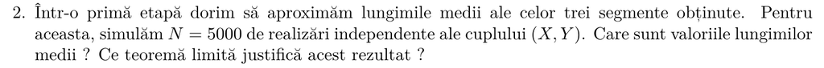

### Solutie

#### Justificare practica

Folosim tot ce am generat punctele anterioare si apelam functia creata pentru acest punct.

```r
# means for a, b, c
get_mean_lengths(dataframe)
```

```
## [1] "all a's mean: 0.336544737908663"
## [1] "all b's mean: 0.325856696138997"
## [1] "all c's mean: 0.33759856595234"
```

Dupa cum observati, valorile lugimilor medii sunt intotdeauna `0.33` approximativ. Uneori mai apare si `0.32` sau `0.34`.

## Procedura 1 - Punctul 3.a

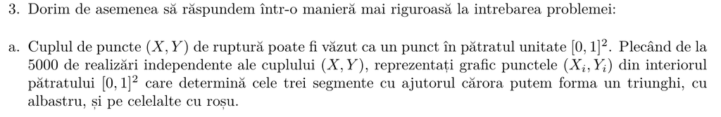

### Solutie

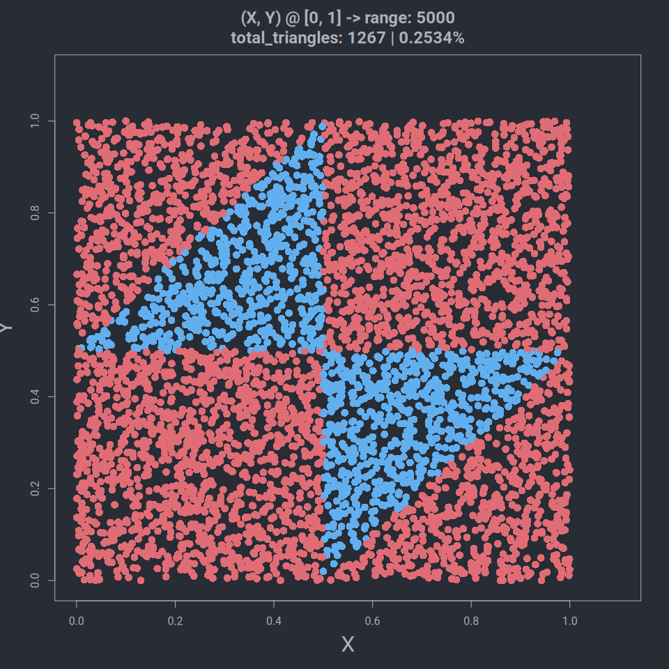

```r
# avem nevoie de nr total de obtuze si triunghiuri pentru a face un plot mai sugestiv
total_triangles <- length(which(dataframe$triangle==TRUE))
triangle_prob <- get_total_triangles_probability(dataframe, total)

# cream titlu pentru plot
main_text <- paste(
    "(X, Y) @ [0, 1] -> range: ",
    total,
    "\n",
    "total_triangles: ",
    total_triangles,
    " | ",
    triangle_prob, "%",
    sep="")

white <- "#ABB2BF"
# setam culoare de background si foreground pentru plot
par(bg = "#282C34", fg=white)

# plotam rezultatele finale
plot(
    x = dataframe$x,
    y = dataframe$y,
    xlab = "X",
    ylab = "Y",
    xlim = c(0,1.1),
    ylim = c(0,1.1),
    main = main_text, # titlu pentru plot
    col.main = white,
    col.sub = white,       # Subtitle color
    col.lab = white,    # X and Y-axis labels color
    col.axis = white,   # Tick labels color
    col = dataframe$color,
    pch = 16,
    cex = 1.5,
    cex.main = 1.5,   # Title size
    cex.sub = 0.5,  # Subtitle size
    cex.lab = 2,   # X-axis and Y-axis labels size
    cex.axis = 1, # Axis labels size
    # family = "monaco"
)
```

Plotare pentru 5000 de generari random de X si Y din Uniform[0, 1]. Graficul este simetric deci inseamna ca este corect. Daca nu facem swap la valorile X si Y atunci graficul este asimetric, deci incorect.

## Procedura 1 - Punctul 3.b

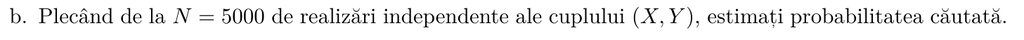

### Solutie

```r
# calcuam probabilitatea pentru formare triunghiuri
triangle_prob <- get_total_triangles_probability(dataframe, total)
cat(triangle_prob)
```

```
## 0.2534
```

Dupa cum observati, este mereu approx `0.25%`, adica `1/4`. Uneori este si `0.24` sau `0.26`.

## Procedura 1 - Punctul 3c

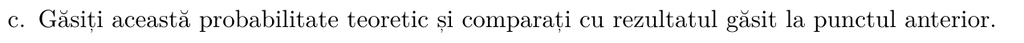

## Procedura 1 - Punctul 4

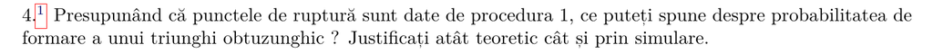

### Justificare practica

```r
# calcuam probabilitatea pentru formare triunghiuri obtuze din toate punctele
obtuses_prob_from_all_points <- get_total_obtuses_probability_from_all_points(dataframe, total)
print(obtuses_prob_from_all_points)
```

```
## [1] 0.1706
```

```r
# calcuam probabilitatea pentru formare triunghiuri obtuze doar din triunghiuri
obtuses_prob_from_triangles <- get_total_obtuses_probability_from_all_triangles(dataframe, total)
print(obtuses_prob_from_triangles)
```

```
## [1] 0.6732439
```

Dupa observati, probabilitatea este mereu approx cu `0.67%`, evident, probabilitatea de formare a triunghiurile obtuze din `toate triunghirile` formate.

## Procedura 2

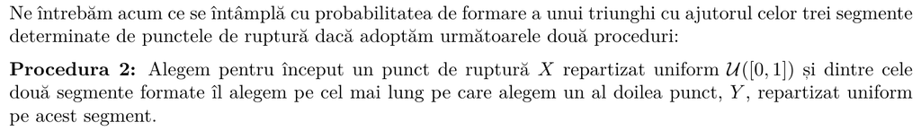

Singura diferenta fata de procedura 1 este modul in care alegem X si Y, in rest toate functiile aplicabile raman la fel. De aceea, au fost facut si asa, pentru reutilizare.

```r
generate_xy_punctul_4 <- function(total = 5000) {
    # 5000 individual unique random values between [0, 1]
    x <- runif(total, 0, 1)
    y <- c()
    for (xx in x) {
        diff_from_0_to_x <- xx
        diff_from_x_to_1 <- abs(1 - xx)
        if (diff_from_0_to_x > diff_from_x_to_1) {
            yy <- runif(1, min=0, max=xx)
        } else {
            yy <- runif(1, min=xx, max=1)
        }
        y <- append(y, yy)
    }
    # why dataframe?
    # its much easier to manage
    return (data.frame(x = x, y = y))
}
```

Generam valorile x si y.

```r
xy <- generate_xy_punctul_4()

# cream dataframe cu tot ce am obtinut
dataframe <- generate_dataframe(
    xy,
    swap=swap)

head(dataframe)
```

```
##            x         y          a          b           c   color triangle
## 1 0.97777946 0.8885423 0.88854227 0.08923719 0.022220535 #E06C75    FALSE
## 2 0.01016626 0.4975211 0.01016626 0.48735480 0.502478939 #E06C75    FALSE
## 3 0.89542234 0.7499279 0.74992788 0.14549446 0.104577656 #E06C75    FALSE
## 4 0.92241629 0.8053539 0.80535389 0.11706240 0.077583710 #E06C75    FALSE
## 5 0.99436049 0.8056849 0.80568492 0.18867558 0.005639506 #E06C75    FALSE
## 6 0.44771597 0.6364131 0.44771597 0.18869708 0.363586946 #61AFEF     TRUE
##   obtuse
## 1  FALSE
## 2  FALSE
## 3  FALSE
## 4  FALSE
## 5  FALSE
## 6   TRUE
```

Am generat valorile si le-am pus in dataframe si am printat primele 6 linii ale dataframe-ului.

## Procedura 2 - Punctul 5

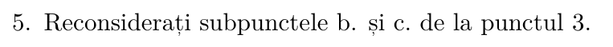

adica aflarea probabilitatii pentru nr total de triunghiuri si demonstratia teoretic

### Justificare practica

Plotam sa vedem distributia de triunghiuri.

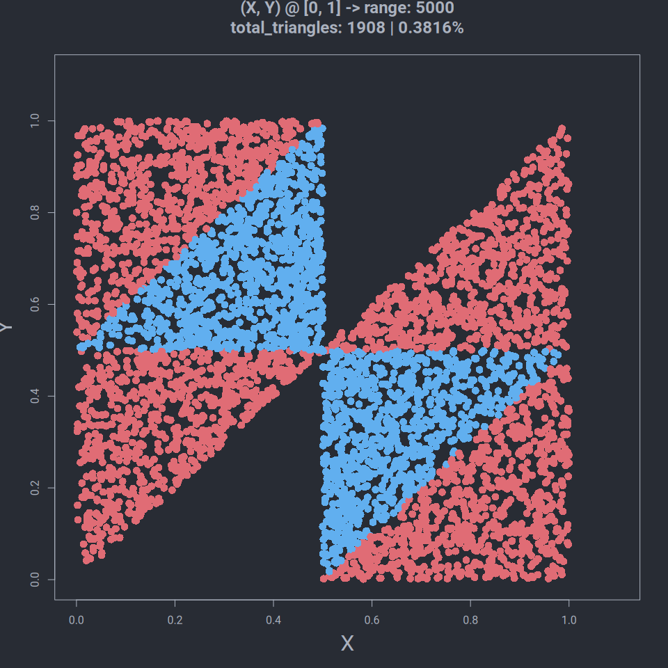

```r
total_triangles <- length(which(dataframe$triangle==TRUE))
triangle_prob <- get_total_triangles_probability(dataframe, total)

# adaugam titlu pentru plot
main_text <- paste(
    "(X, Y) @ [0, 1] -> range: ",
    total,
    "\n",
    "total_triangles: ",
    total_triangles,
    " | ",
    triangle_prob, "%",
    "\n",
    sep="")

# punctul 3.a
size <- 600
white <- "#ABB2BF"
# setam culoare de background si foreground pentru plot
par(bg = "#282C34", fg=white)

# plotam rezultatele finale
plot(
    x = dataframe$x,
    y = dataframe$y,
    xlab = "X",
    ylab = "Y",
    xlim = c(0,1.1),
    ylim = c(0,1.1),
    main = main_text,
    col.main = white,
    col.sub = white,       # Subtitle color
    col.lab = white,    # X and Y-axis labels color
    col.axis = white,   # Tick labels color
    col = dataframe$color,
    pch = 16,
    cex = 1.5,
    cex.main = 1.5,   # Title size
    cex.sub = 0.5,    # Subtitle size
    cex.lab = 2,      # X-axis and Y-axis labels size
    cex.axis = 1,     # Axis labels size
    # family = "monaco"
)
```

calculam probabiliatea de formare pentru triunghiuri cu noua metoda de alegere

```r
total_triangles_prob <- get_total_triangles_probability(dataframe, total)
print(total_triangles_prob)
```

```
## [1] 0.3816
```

Dupa cum se observa probabilitatea este mereu approx cu `0.38%`

## Procedura 2 - Punctul 6

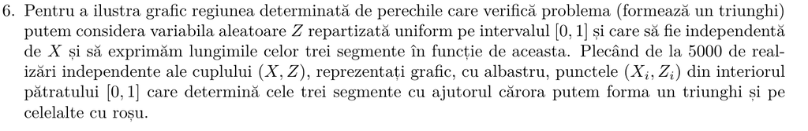

Nu are sens. Este exact ca la procedura 1. Daca citim cerinta o sa reiasa ca rezolvarea este exact la la procedura 1.

Functia de generate X si Z.

```r
generate_xz <- function(total = 5000) {
    # 5000 individual unique random values between [0, 1]
    x <- runif(total, 0, 1)
    # 5000 individual unique random values between [0, 1]
    z <- runif(total, 0, 1)
    # why dataframe?
    # its much easier to manage
    return (data.frame(x = x, y = z))
}
```

Generam valorile X si Z si le salvam in dataframe.

```r
# generam valorile x si z
xz <- generate_xz()

# cream dataframe cu tot ce am obtinut
dataframe <- generate_dataframe(
    xz,
    swap=swap)

head(dataframe)
```

```
##           x         y         a         b           c   color triangle obtuse
## 1 0.7460684 0.5254203 0.5254203 0.2206482 0.253931565 #E06C75    FALSE  FALSE
## 2 0.7539250 0.1574868 0.1574868 0.5964382 0.246075001 #E06C75    FALSE  FALSE
## 3 0.7007661 0.9924278 0.7007661 0.2916617 0.007572188 #E06C75    FALSE  FALSE
## 4 0.5187636 0.9466069 0.5187636 0.4278433 0.053393116 #E06C75    FALSE  FALSE
## 5 0.5868364 0.2056261 0.2056261 0.3812102 0.413163614 #61AFEF     TRUE  FALSE
## 6 0.1750778 0.7942144 0.1750778 0.6191366 0.205785612 #E06C75    FALSE  FALSE
```

Plotam valorile.

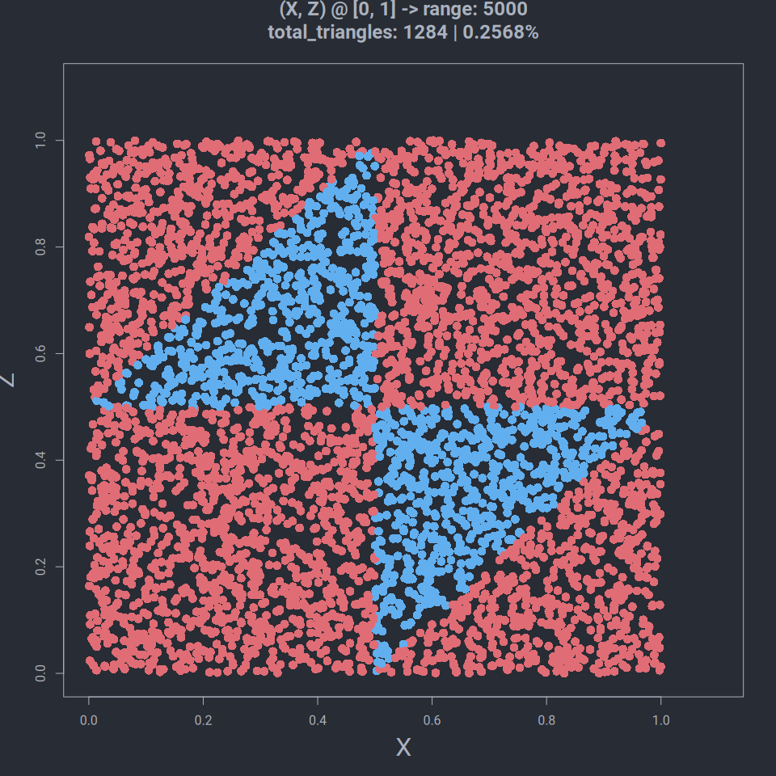

```r
total_triangles <- length(which(dataframe$triangle==TRUE))
triangle_prob <- get_total_triangles_probability(dataframe, total)
# adaugam titlu pentru plot
main_text <- paste(
    "(X, Z) @ [0, 1] -> range: ",
    total,
    "\n",
    "total_triangles: ",
    total_triangles,
    " | ",
    triangle_prob, "%",
    "\n",
    sep="")

# punctul 3.a
size <- 600
white <- "#ABB2BF"
# setam culoare de background si foreground pentru plot
par(bg = "#282C34", fg=white)

# plotam rezultatele finale
plot(
    x = dataframe$x,
    y = dataframe$y,
    xlab = "X",
    ylab = "Z",
    xlim = c(0,1.1),
    ylim = c(0,1.1),
    main = main_text,
    col.main = white,
    col.sub = white,       # Subtitle color
    col.lab = white,    # X and Y-axis labels color
    col.axis = white,   # Tick labels color
    col = dataframe$color,
    pch = 16,
    cex = 1.5,
    cex.main = 1.5,   # Title size
    cex.sub = 0.5,    # Subtitle size
    cex.lab = 2,      # X-axis and Y-axis labels size
    cex.axis = 1,     # Axis labels size
)
```

## Procedura 3

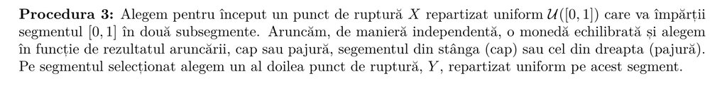

Singura diferenta fata de procedura 1 si 2 este modul in care alegem X si Y, in rest toate functiile aplicabile raman la fel. De aceea, au fost facut si asa, pentru reutilizare.

Pentru aceasta procedura avem nevoie de o functie care sa selecteze random cap sau pajura

```r
select_cap_sau_pajura_random <- function() {
    data <- c("cap", "pajura")
    result <- sample(x=data, size=1)
    if (result == "cap") {
        return ("stanga")
    }
    return ("dreapta")
}
```

Functia de generare (X, Y)

```r
generate_xy_procedura_3 <- function(total = 5000) {
    # 5000 individual unique random values between [0, 1]
    x <- runif(total, 0, 1)
    y <- c()
    for (xx in x) {
        zona <- select_cap_sau_pajura_random()
        if (zona == "stanga") {
            yy <- runif(1, min=0, max=xx)
        } else {
            yy <- runif(1, min=xx, max=1)
        }
        y <- append(y, yy)
    }
    # why dataframe?
    # its much easier to manage
    return (data.frame(x = x, y = y))
}
```

generam si valorile necesare

```r
# generam valorile x si y
xy <- generate_xy_procedura_3()

# cream dataframe cu tot ce am obtinut
dataframe <- generate_dataframe(
    xy,
    swap=swap)

head(dataframe)
```

```
##            x           y           a           b         c   color triangle
## 1 0.13618851 0.353515449 0.136188514 0.217326935 0.6464846 #E06C75    FALSE
## 2 0.60170621 0.463577201 0.463577201 0.138129011 0.3982938 #61AFEF     TRUE
## 3 0.01055787 0.005352054 0.005352054 0.005205817 0.9894421 #E06C75    FALSE
## 4 0.79870634 0.617591446 0.617591446 0.181114889 0.2012937 #E06C75    FALSE
## 5 0.42401220 0.627167888 0.424012204 0.203155683 0.3728321 #61AFEF     TRUE
## 6 0.23933388 0.030896080 0.030896080 0.208437804 0.7606661 #E06C75    FALSE
##   obtuse
## 1  FALSE
## 2   TRUE
## 3  FALSE
## 4  FALSE
## 5  FALSE
## 6  FALSE
```

## Procedura 3 - Punctul 7 - 5 (punctul 5 care se repeta)

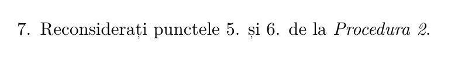

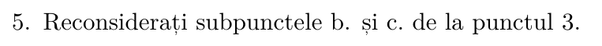

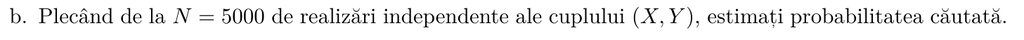

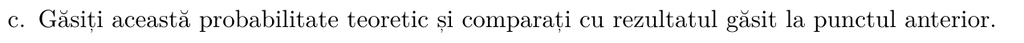

### Solutie

Plotam sa vedem distributia de triunghiuri.

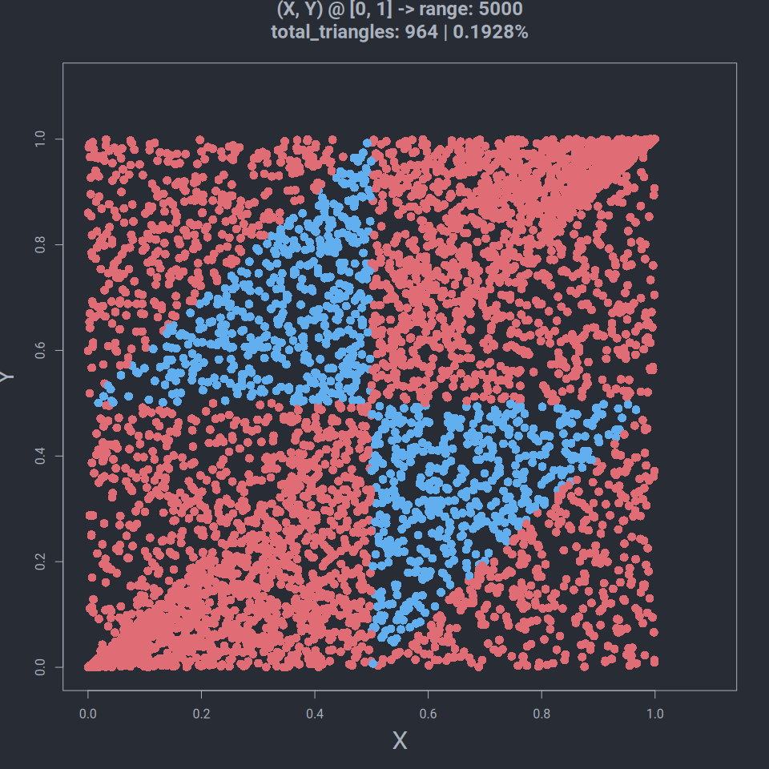

```r
# variable pentru plot
total_triangles <- length(which(dataframe$triangle==TRUE))
total_obtuses <- length(which(dataframe$obtuse==TRUE))
triangle_prob <- get_total_triangles_probability(dataframe, total)

# adaugam titlu pentru plot
main_text <- paste(
    "(X, Y) @ [0, 1] -> range: ",
    total,
    "\n",
    "total_triangles: ",
    total_triangles,
    " | ",
    triangle_prob, "%",
    "\n",
    sep="")

# punctul 3.a
size <- 600
white <- "#ABB2BF"
# setam culoare de background si foreground pentru plot
par(bg = "#282C34", fg=white)

# plotam rezultatele finale
plot(
    x = dataframe$x,
    y = dataframe$y,
    xlab = "X",
    ylab = "Y",
    xlim = c(0,1.1),
    ylim = c(0,1.1),
    main = main_text,
    col.main = white,
    col.sub = white,       # Subtitle color
    col.lab = white,    # X and Y-axis labels color
    col.axis = white,   # Tick labels color
    col = dataframe$color,
    pch = 16,
    cex = 1.5,
    cex.main = 1.5,   # Title size
    cex.sub = 0.5,    # Subtitle size
    cex.lab = 2,      # X-axis and Y-axis labels size
    cex.axis = 1,     # Axis labels size
    # family = "monaco"
)
```

Dupa cum observati foarte multe puncte sunt localizare in colturile stanga jos si dreapta sus.

## Procedura 3 - Punctul 7 - 6 (punctul 6 care se repeta)

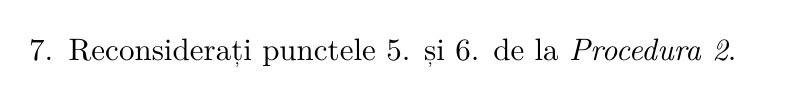

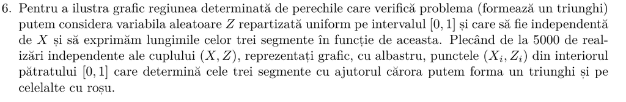

Nu are sens. Este exact ca la procedura 1. Daca citim cerinta o sa reiasa ca rezolvarea este exact la la procedura 1.

Functia de generate X si Z.

```r
generate_xz <- function(total = 5000) {
    # 5000 individual unique random values between [0, 1]
    x <- runif(total, 0, 1)
    # 5000 individual unique random values between [0, 1]
    z <- runif(total, 0, 1)
    # why dataframe?
    # its much easier to manage
    return (data.frame(x = x, y = z))
}
```

Generam valorile X si Z si le salvam in dataframe.

```r
# generam valorile x si z
xz <- generate_xz()

# cream dataframe cu tot ce am obtinut
dataframe <- generate_dataframe(
    xz,
    swap=swap)

head(dataframe)
```

```
##           x          y          a           b         c   color triangle obtuse
## 1 0.8677519 0.21850291 0.21850291 0.649249007 0.1322481 #E06C75    FALSE  FALSE
## 2 0.1503526 0.63282631 0.15035262 0.482473690 0.3671737 #61AFEF     TRUE   TRUE
## 3 0.3547994 0.35068391 0.35068391 0.004115447 0.6452006 #E06C75    FALSE  FALSE
## 4 0.6224516 0.57620407 0.57620407 0.046247562 0.3775484 #E06C75    FALSE  FALSE
## 5 0.8956184 0.65285669 0.65285669 0.242761699 0.1043816 #E06C75    FALSE  FALSE
## 6 0.4935031 0.04181514 0.04181514 0.451687926 0.5064969 #E06C75    FALSE  FALSE
```

Plotam valorile.

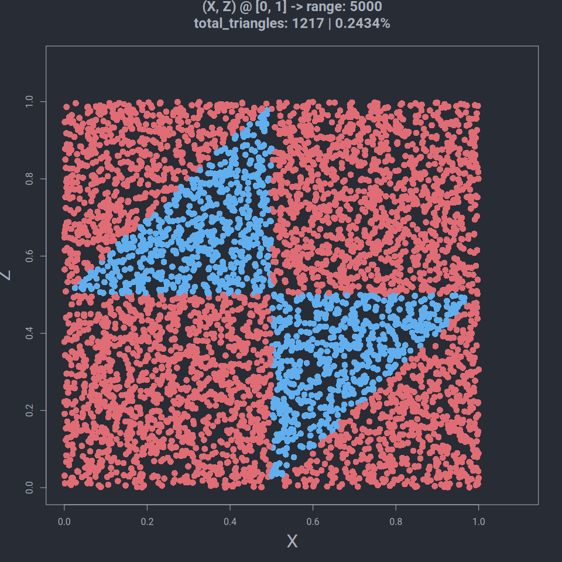

```r
total_triangles <- length(which(dataframe$triangle==TRUE))
triangle_prob <- get_total_triangles_probability(dataframe, total)
# adaugam titlu pentru plot
main_text <- paste(
    "(X, Z) @ [0, 1] -> range: ",
    total,
    "\n",
    "total_triangles: ",
    total_triangles,
    " | ",
    triangle_prob, "%",
    "\n",
    sep="")

# punctul 3.a
size <- 600
white <- "#ABB2BF"
# setam culoare de background si foreground pentru plot
par(bg = "#282C34", fg=white)

# plotam rezultatele finale
plot(
    x = dataframe$x,
    y = dataframe$y,
    xlab = "X",
    ylab = "Z",
    xlim = c(0,1.1),
    ylim = c(0,1.1),
    main = main_text,
    col.main = white,
    col.sub = white,       # Subtitle color
    col.lab = white,    # X and Y-axis labels color
    col.axis = white,   # Tick labels color
    col = dataframe$color,
    pch = 16,
    cex = 1.5,
    cex.main = 1.5,   # Title size
    cex.sub = 0.5,    # Subtitle size
    cex.lab = 2,      # X-axis and Y-axis labels size
    cex.axis = 1,     # Axis labels size
)
```

# Problema 2

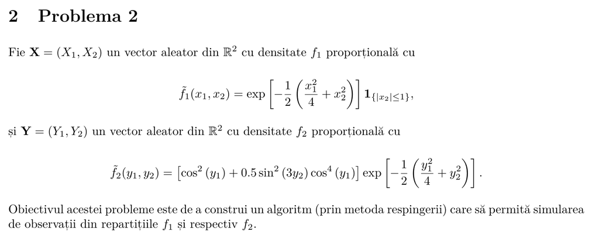

Definim si functiile cu caciula in R.

```r
f1_caciula <- function(x1, x2) {
    result <- exp((-1 / 2) * (((x1 ^ 2) / 4) + (x2 ^ 2)))
    return (result)
}


f2_caciula <- function(y1, y2) {
    # exp_ <- exp((-1 / 2) * (((y1 ^ 2) / 4) + (y2 ^ 2)))
    exp_ <- f1_caciula(y1, y2)
    cos_sin <- (cos(y1) ^ 2) + (0.5 * (sin(3 * y2) ^ 2) * (cos(y1) ^ 4))

    return (exp_ * cos_sin)
}
```

Definim `g(x)` si functia raport `r(x)`.

```r
g <- function(x1, x2) {
    result <- exp((-x1 / 2) - x2)
    return (result)
}

raport_f1 <- function(x1, x2) {
    return (f1(x1, x2) / g(x1, x2))
}

raport_f2 <- function(x1, x2) {
    return (f2(x1, x2) / g(x1, x2))
}
```

Si mai definim si functia densitate, i.e. `f(x)`

```r
# f = f caciula * c
# fie c = 1
f1 <- f1_caciula
f2 <- f2_caciula
```

# Problema 2 - Punctul 1

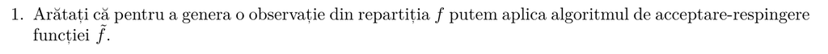

### Solutie

# Problema 2 - Punctul 2

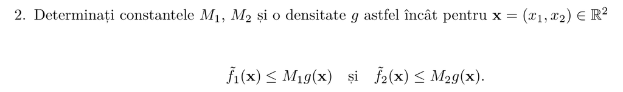

### Solutie

### Demonstratie matematica/teoretica

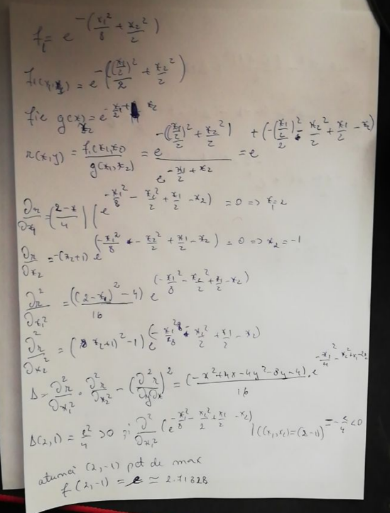

### Demonstratie practica

```r
M1 <- raport_f1(2, 1)


raport_M1 <- function(x1, x2) {
    return (f1(x1, x2) / (M1 * g(x1, x2)))
}

print(M1)
```

```
## [1] 2.718282
```

# Problema 2 - Punctul 3

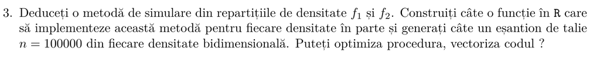

Rejection sampling pentru functia f1

### Solutie

```r
# esantion de lungime 100000
x1_accepted <- c()
x2_accepted <- c()
n <- 100000
total_repeats <- 0
for (i in 1:n) {
    # acceptance_prob
    repeat {
        u1 <- runif(1)
        u2 <- runif(1)
        # x1 <- -(1/2) * log(rexp(1))
        # x2 <- log(rexp(1))

        x1 <- 1 + sqrt(-log(u1))
        x2 <- 1 + sqrt(-5.4 * log(u2))

        total_repeats <- total_repeats + 1

        if((u1 * u2) < raport_M1(x1, x2)) {
            break
        }
    }
    x1_accepted <- append(x1_accepted, x1)
    x2_accepted <- append(x2_accepted, x2)
}
acceptance_prob <- n / total_repeats
print(acceptance_prob)
```

```
## [1] 0.3617997
```

Probabilitatea de acceptare este approx `0.36%` intotdeauna, adica `1/M`, care `M` este `e`.